# Similar resources

- https://mlr3book.mlr-org.com/03-perf-binary.html

# German Credit Dataset

# Goal

In this exercise, we will create a machine learning model that predicts the credit risk of an individual (e.g., the probability of being a `good` or `bad` credit applicant for the bank). Our goal is not to obtain an optimal classifier for this task, but to learn how to get a better understanding of the predictions made by this model. This means looking at its sensitivity (ability to correctly identify positives) and specificity (ability to correctly identify negatives). The sensitivity is also known as the true positive rate (TPR) and the specificity is equal to (1 - FPR) where FPR is the false positive rate.

We will also cover how to obtain different response predictions from a probabilistic model by modifying the threshold. We will inspect this relationship via the ROC curve and tune the threshold for a given classifier to optimize our response predictions.

# Exercises

First load the pre-defined german credit task and set the positive class to `"good"`. Train a random forest on 2/3 of the data (training data) and make probabilistic predictions on the remaining 1/3 (test data).

**Hint 1:**

- Create the german credit task using `tsk()` and set the positive class by modifying e.g. `task$positive`.
- Create a learner using `lrn()` and make sure to specify the `predict_type` so that the learner will predict probabilities instead of classes.
- When calling the methods `$train()` and `$predict()` of the learner, you can pass an argument `row_ids` to specify which observations should be used for the train and test data.
- You can generate random train-test splits using, e.g., the `partition()` function.

**Hint 2:**

```r
library(mlr3verse)

task = tsk(...)
task$positive = ...
learner = lrn(..., predict_type = ...)
ids = partition(...)
learner$train(..., row_ids = ...)
pred = learner$predict(..., row_ids = ...)
```

### Solution:

**Click me:**

```r
library(mlr3verse)
task = tsk("german_credit")
task$positive = "good"
learner = lrn("classif.ranger", predict_type = "prob")
ids = partition(task)
str(ids)
```

```
## List of 2
##  $ train: int [1:670] 7 8 13 17 18 20 21 22 24 27 ...
##  $ test : int [1:330] 1 3 4 6 9 15 23 25 26 31 ...
```

```r
learner$train(task, row_ids = ids$train)
pred = learner$predict(task, row_ids = ids$test)
pred
## <PredictionClassif> for 330 observations:
##     row_ids truth response prob.good  prob.bad
##           1  good     good 0.8230016 0.1769984
##           3  good     good 0.8919516 0.1080484
##           4  good      bad 0.4713484 0.5286516
## ---
##         953   bad     good 0.6843794 0.3156206
##         982   bad     good 0.5343651 0.4656349
##         999   bad      bad 0.3224706 0.6775294
```

## Confusion matrices and classification thresholds

Inspect and save the confusion matrix of the predictions made in the previous exercise. Manually calculate the FPR and TPR using the values from the confusion matrix. Can you think of another way to compute the TPR and FPR using `mlr3` instead of manually computing them using the confusion matrix?

**Recap**

A confusion matrix is a special kind of contingency table with two dimensions “actual” and “predicted” to summarize the ground truth classes (truth) vs. the predicted classes of a classifier (response).

Binary classifiers can be understood as first predicting a score (possibly a probability) and then classifying all instances with a score greater than a certain threshold $t$ as positive and all others as negative. This means that one can obtain different class predictions using different threshold values $t$.

**Hint 1:**

A prediction object has a field `$confusion`. Since `good` was used as the positive class here, the TPR is $P(\hat{Y} = good | Y = good)$ and the FPR is $P(\hat{Y} = good | Y = bad)$ (where $\hat{Y}$ refers to the predicted response of the classifier and $Y$ to the ground truth class labels). Instead of manually computing the TPR and FPR, there are appropriate performance measures implemented in `mlr3` that you could use.

**Hint 2:**

You need to replace `...` in the code below to access the appropriate columns and rows, e.g., `confusion1[1, 1]` is the element in the first row and first column of the confusion matrix and tells you how many observations with ground truth $Y = good$ were classified into the class $\hat{Y} = good$ by the learner.

```r
confusion1 = pred$confusion
TPR1 =  confusion1[...] / sum(confusion1[...])
TPR1
FPR1 = confusion1[...] / sum(confusion1[...])
FPR1
```

The names of the TPR and FPR performance measures implemented in `mlr3` can be found by looking at `as.data.table(mlr_measures)`. You can use the code below and pass the names of the `mlr3` measures in a vector to compute both the TPR and FPR:

```r
pred$score(msrs(...))
```

### Solution:

**Click me:**

```r
confusion1 = pred$confusion
TPR1 = confusion1[1, 1] / sum(confusion1[, 1])
TPR1
```

```
## [1] 0.9177489
```

```r
FPR1 = confusion1[1, 2] / sum(confusion1[, 2])
FPR1
```

```
## [1] 0.5959596
```

Instead of manually computing the TPR and FPR, you could also just use

```r
pred$score(msrs(c("classif.tpr", "classif.fpr")))
## classif.tpr classif.fpr
##   0.9177489   0.5959596
```

## Asymmetric costs

Think about which type of error is worse for the given task and obtain new predictions (without retraining the model) that takes this into account.

Then calculate the FPR and TPR and compare it with the results from the previous exercise.

**Hint 1:**

A prediction object has the method `$set_threshold()` that can be used to set a custom threshold and which will update the predicted classes according to the selected threshold value.

**Hint 2:**

```r
pred$set_threshold(...)
confusion2 = pred$confusion
TPR2 =  confusion2[...] / sum(...)
FPR2 = confusion2[...] / sum(...)

TPR2 - TPR1
FPR2 - FPR1
```

### Solution:

**Click me:**

The error of making a false positive - in this case classifying someone who is not creditworthy ($Y = bad$) as creditworthy ($\hat Y = good$) - is likely considerably higher than classifying someone who is creditworthy as not creditworthy. In the first scenario, the company may lose all the money that was not paid back duly. In the letter case, it only misses out on the profit.

We can take this fact into account by using a higher threshold to predict the positive class (`good`), i.e., being more conservative in classifying a good credit risk. For illustration purposes, we will use the threshold $0.7$ which is higher than the default threshold $0.5$.

```r
pred$set_threshold(0.7)
pred
## <PredictionClassif> for 330 observations:
##     row_ids truth response prob.good  prob.bad
##           1  good     good 0.8230016 0.1769984
##           3  good     good 0.8919516 0.1080484
##           4  good      bad 0.4713484 0.5286516
## ---
##         953   bad      bad 0.6843794 0.3156206
##         982   bad      bad 0.5343651 0.4656349
##         999   bad      bad 0.3224706 0.6775294
```

We can then access the updated confusion matrix and calculate the new FPR and TPR as before.

```r
confusion2 = pred$confusion
TPR2 =  confusion2[1, 1] / sum(confusion2[, 1])
FPR2 = confusion2[1, 2] / sum(confusion2[, 2])
```

When comparing it with the previous values, we observe a lower TPR and FPR.

```r
TPR2 - TPR1
```

```
## [1] -0.2640693
```

```r
FPR2 - FPR1
```

```
## [1] -0.3030303
```

## ROC curve

In the previous two exercises, we have calculated the FPR and TPR for two thresholds. Now visualize the FPR and TPR for all possible thresholds, i.e. the ROC curve.

**Recap**

The receiver operating characteristic (ROC) displays the sensitivity and specificity for all possible thresholds.

**Hint 1:**

You can use `autoplot()` on the prediction object and set the `type` argument to produce a ROC curve. You can open the help page of `autoplot` for a prediction object using `?mlr3viz::autoplot.PredictionClassif`.

**Hint 2:**

```r
autoplot(pred, type = ...)
```

### Solution:

**Click me:**

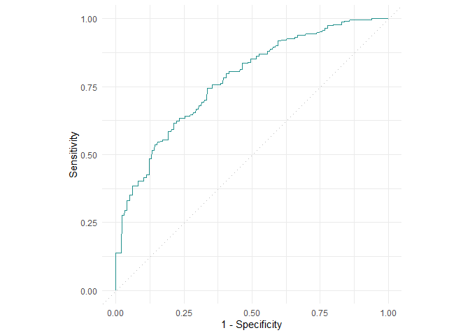

```r
autoplot(pred, type = "roc")
```

## Threshold tuning

In this exercise, we assume that predicting a false positive is 4 times worse than a false negative. Use a measure that considers classification costs (e.g., misclassification costs `msr("classif.costs")$help()`) and tune the threshold of our classifier to systematically optimize the asymmetric cost function. To do so, create predictions for all thresholds 0, 0.01, 0.02, …, 1 and find the threshold that minimizes this measure. Summarize the evaluated scores for these thresholds in a plot.

You can use the following code as a starting point.

```r
# Define the sequence of threshold values
thresholds = seq(0, 1, by = 0.01)

# The function below takes a:
#   * prediction object
#   * threshold value (scalar value between 0 and 1)
#   * measure object
#   * task object
# It then gets new predictions for the given threshold and calculates the score of the specified measure.
# Note that it modifies the prediction in place.
eval_threshold = function(pred, threshold, measure, task) {
  pred$set_threshold(threshold)
  score = pred$score(measure, task = task)
  return(score)
}

# Example of the usage of `eval_threshold` with the FPR measure
eval_threshold(pred, threshold = 0.5, measure = msr("classif.fpr"), task = task)
eval_threshold(pred, threshold = 0.7, measure = msr("classif.fpr"), task = task)
```

**Hint 1:**

Read the examples of `msr("classif.costs")$help()` to learn how to define the cost function. Use `sapply()` (or a for loop) in combination with the `eval_threshold` function above to compute the misclassification costs for the sequence of different threshold values. You can use `which.min` to find the index of a vector with the minimum value.

**Hint 2:**

```r
library(ggplot2)
costs = matrix(c(...), nrow = 2)
dimnames(costs) = list(truth = ..., response = ...)
measure = msr(...)
scores = sapply(thresholds, function(threshold) eval_threshold(...))

thresholds[which.min(...)]
min(...)
qplot(x = ..., y = ...)
```

### Solution:

**Click me:**

We start with defining the thresholds we want to evaluate and the function that returns the metric for each threshold.

```r
library(ggplot2)
thresholds = seq(0, 1, by = 0.01)
eval_threshold = function(pred, threshold, measure, task) {
  pred$set_threshold(threshold)
  score = pred$score(measure, task = task)
  return(score)
}
```

We then define the cost matrix and from it the cost function.

```r
costs = matrix(c(0, 1, 4, 0), nrow = 2)
dimnames(costs) = list(truth = task$class_names, response = task$class_names)
measure = msr("classif.costs", costs = costs)
```

Finally we evaluate each threshold, find the minimum and plot the results.

```r
scores = sapply(thresholds, function(threshold) eval_threshold(pred, threshold, measure, task))
thresholds[which.min(scores)]
```

```
## [1] 0.77
```

```r
min(scores)
```

```
## [1] 0.4969697
```

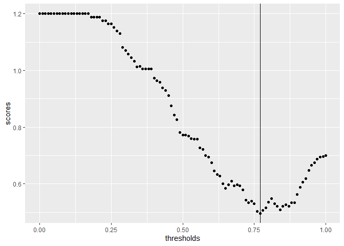

```r
qplot(x = thresholds, y = scores) + geom_vline(xintercept = thresholds[which.min(scores)])
```

## ROC Comparison

In this exercise, we will explore how to compare to learners by looking at their ROC curve.

The basis for this exercise will be a benchmark experiment that compares a classification tree with a random forest on the german credit task.

Because we are now not only focused on the analysis of a given prediction, but on the comparison of two learners, we selected a 10-fold cross-validation to reduce the uncertainty of this comparison.

Conduct the benchmark experiment and show both ROC curves in one plot. Which learner learner performs better in this case?

**Hint 1:**

Use `benchmark_grid()` to create the experiment design and execute it using `benchmark()`. You can also apply the function `autoplot()` to benchmark results.

**Hint 2:**

```r
resampling = rsmp(..)
learners = lrns(...)
design = benchmark_grid(...)
bmr = benchmark(...)
autoplot(...)
```

### Solution:

**Click me:**

We create and execute the benchmark experiment in the usual fashion.

```r
resampling = rsmp("cv", folds = 10)
learners = list(
  lrn("classif.rpart", predict_type = "prob"),
  lrn("classif.ranger", predict_type = "prob")
)
design = benchmark_grid(task, learners, resampling)
bmr = benchmark(design)
```

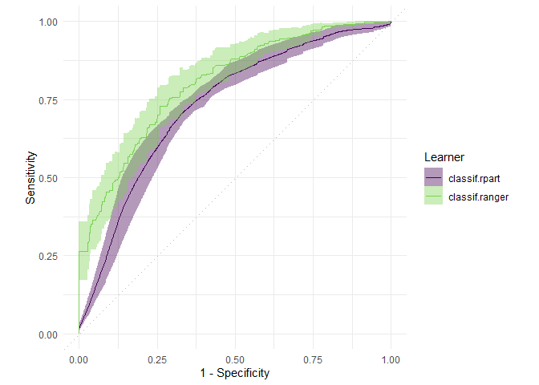

```r
autoplot(bmr, type = "roc")
```

The random forest is clearly better, as for virtually every specificity it has a higher sensitivity.

## Area under the curve

In the previous exercise we have learned how to compare to learners using the ROC curve. Although the random forest was dominating the classification tree in this specific case, the more common case is that the ROC curves of two models are crossing, making a comparison in the sense of $>$ / $<$ impossible.

The area under the curve tries to solve this problem by summarizing the ROC curve by its area under the curve (normalized to 1), which allows for a scalar comparison.

Compare the AUC for the benchmark result.

**Hint 1:**

You can use the `autoplot()` function and use the AUC as performance measure in the `measure` argument.

**Hint 2:**

```r
autoplot(bmr, measure = msr(...))
```

### Solution:

**Click me:**

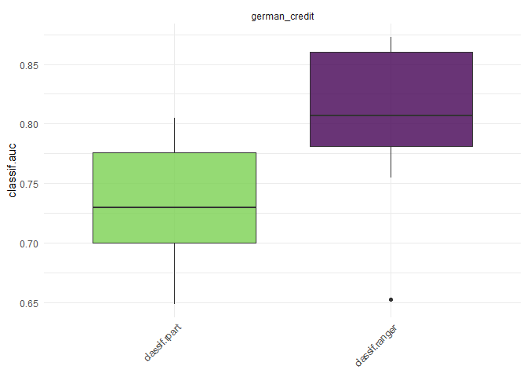

```r
autoplot(bmr, measure = msr("classif.auc"))
```

As expected, the AUC for the random forest is higher than the AUC for the classification tree.

## Bonus exercise: Unbiased performance estimation

Revisit the exercise where we tuned the threshold. Is the performance estimate for the best threshold unbiased? If no, does this mean that our tuning strategy was invalid?

**Hint 1:**

Did we use an independent test set?

**Hint 2:**

Think of the uncertainty when estimating the ROC curve.

### Solution:

**Click me:**

No, although our method is valid with respect to determining our “best guess” for the optimal threshold, the obtained performance estimate suffers from optimization bias. We would need an independent test set to evaluate our method, i.e. nested holdout or cross-validation.

# Summary

In this exercise we improved our understanding of the performance of binary classifiers by the means of the confusion matrix and a focus on different error types. We have seen how we can analyze and compare classifiers using the ROC and how to improve our response predictions using threshold tuning.